## Evaluate simple linear regression

Dataset called **Dummy Marketing and Sales Data**, retrieved from [Kaggle](https://www.kaggle.com/datasets/harrimansaragih/dummy-advertising-and-sales-data) but modified for training pupose This Dataset represents the amount of money spent on TV, radio, and social media promotions, as well as the corresponding sales.

### Import Dataset

```python
import pandas as pd
import matplotlib.pyplot as plt
import seaborn as sns
import statsmodels.api as sm
from statsmodels.formula.api import ols
```

```python
data= pd.read_csv('marketing_and_sales_data_evaluate_lr.csv')
data.head()
```

|  | TV | Radio | Social_Media | Sales |
| --- | --- | --- | --- | --- |
| 0 | 16.0 | 6.566231 | 2.907983 | 54.732757 |
| 1 | 13.0 | 9.237765 | 2.409567 | 46.677897 |
| 2 | 41.0 | 15.886446 | 2.913410 | 150.177829 |
| 3 | 83.0 | 30.020028 | 6.922304 | 298.246340 |
| 4 | 15.0 | 8.437408 | 1.405998 | 56.594181 |

### Data Exploration

```python
data.shape
```

```
(4572, 4)
```

```python
data[['TV','Radio','Social_Media']].describe()
```

|  | TV | Radio | Social_Media |
| --- | --- | --- | --- |
| count | 4562.000000 | 4568.000000 | 4566.000000 |
| mean | 54.066857 | 18.160356 | 3.323956 |
| std | 26.125054 | 9.676958 | 2.212670 |
| min | 10.000000 | 0.000684 | 0.000031 |
| 25% | 32.000000 | 10.525957 | 1.527849 |
| 50% | 53.000000 | 17.859513 | 3.055565 |
| 75% | 77.000000 | 25.649730 | 4.807558 |
| max | 100.000000 | 48.871161 | 13.981662 |

```python
# Calculate the average missing rate in the sales column.
missing_sales = data.Sales.isna().mean()
```

```python
# Convert the missing_sales from a decimal to a percentage and round to 2 decimal places.
missing_sales = round(missing_sales*100,2)
```

```python
print('Percentage of promotions missing Sales: ' + str(missing_sales)+'%')
```

```
Percentage of promotions missing Sales: 0.13%
```

```python
data = data.dropna(subset = ['Sales'], axis = 0)
```

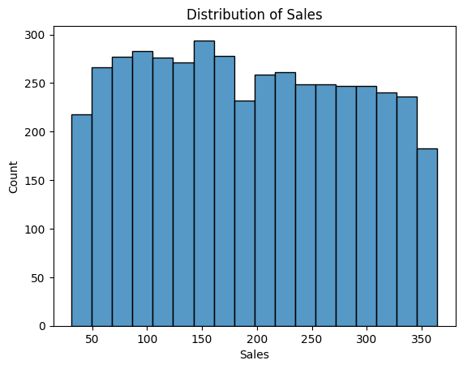

```python
# Create a histogram of the Sales.

fig = sns.histplot(data['Sales'])

# Add a title
fig.set_title('Distribution of Sales');
```

### Model Building

Create a **pairplot** to visualize the relationships between pairs of variables in the data. Use this to visually determine which variable has the strongest linear relationship with Sales.

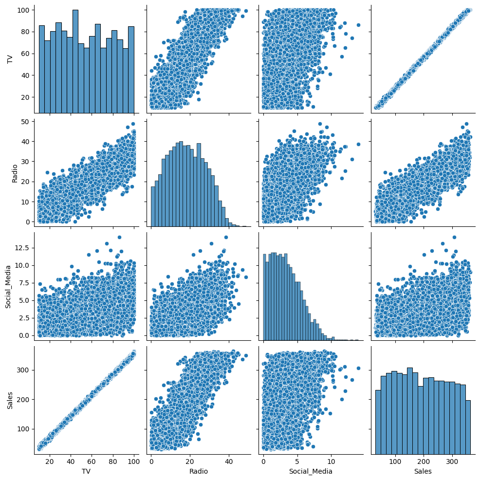

```python
# Create a pairplot of the data.
sns.pairplot(data);
```

As the graph showed, `TV` has the strongest linear relationship with `Sales`.

```python
# Define the OLS formula.
ols_formula = 'Sales ~ TV'

# Create an OLS model.
OLS = ols(formula = ols_formula, data = data)

# Fit the model.
model = OLS.fit()

# Save the results summary.
model_results = model.summary()

# Display the model results.
model_results
```

OLS Regression Results

| Dep. Variable: | Sales | R-squared: | 0.999 |
| --- | --- | --- | --- |
| Model: | OLS | Adj. R-squared: | 0.999 |
| Method: | Least Squares | F-statistic: | 4.527e+06 |
| Date: | Fri, 20 Oct 2023 | Prob (F-statistic): | 0.00 |
| Time: | 19:11:36 | Log-Likelihood: | -11393. |
| No. Observations: | 4556 | AIC: | 2.279e+04 |
| Df Residuals: | 4554 | BIC: | 2.280e+04 |
| Df Model: | 1 |  |  |
| Covariance Type: | nonrobust |  |  |

|  | coef | std err | t | P>\|t\| | [0.025 | 0.975] |
| --- | --- | --- | --- | --- | --- | --- |
| Intercept | -0.1263 | 0.101 | -1.257 | 0.209 | -0.323 | 0.071 |
| TV | 3.5614 | 0.002 | 2127.776 | 0.000 | 3.558 | 3.565 |

| Omnibus: | 0.051 | Durbin-Watson: | 2.002 |
| --- | --- | --- | --- |
| Prob(Omnibus): | 0.975 | Jarque-Bera (JB): | 0.030 |
| Skew: | 0.001 | Prob(JB): | 0.985 |
| Kurtosis: | 3.012 | Cond. No. | 138. |

Notes:  
[1] Standard Errors assume that the covariance matrix of the errors is correctly specified.

#### Check model assumptions

To justify using simple linear regression, check that the four linear regression assumptions are not violated. These assumptions are:

- Linearity
- Independent Observations
- Normality
- Homoscedasticity

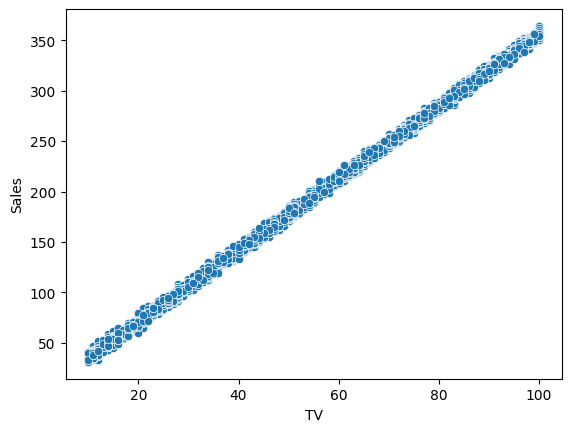

```python
# Create a scatterplot comparing X and Sales (Y).
sns.scatterplot(x = data['TV'], y = data['Sales']);
```

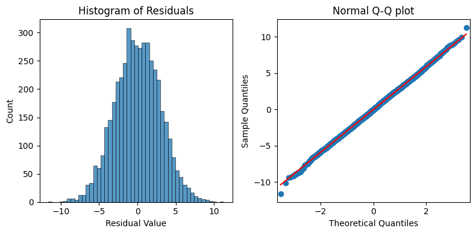

```python
# Calculate the residuals.
residuals = model.resid

# Create a 1x2 plot figure.
fig, axes = plt.subplots(1, 2, figsize = (8,4))

# Create a histogram with the residuals .
sns.histplot(residuals, ax=axes[0])

# Set the x label of the residual plot.
axes[0].set_xlabel("Residual Value")

# Set the title of the residual plot.
axes[0].set_title("Histogram of Residuals")

# Create a Q-Q plot of the residuals.
sm.qqplot(residuals, line='s',ax = axes[1])

# Set the title of the Q-Q plot.
axes[1].set_title("Normal Q-Q plot")

# Use matplotlib's tight_layout() function to add space between plots for a cleaner appearance.
plt.tight_layout()

# Show the plot.
plt.show()
```

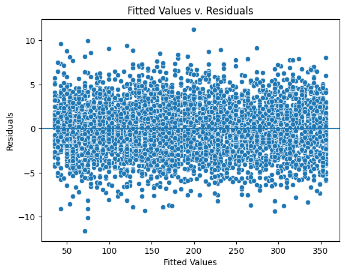

```python
# Create a scatterplot with the fitted values from the model and the residuals.
fig = sns.scatterplot(x = model.fittedvalues, y = model.resid)

# Set the x-axis label.
fig.set_xlabel("Fitted Values")

# Set the y-axis label.
fig.set_ylabel("Residuals")

# Set the title.
fig.set_title("Fitted Values v. Residuals")

# Add a line at y = 0 to visualize the variance of residuals above and below 0.
fig.axhline(0)

# Show the plot.
plt.show()
```

The variance of the residuals is consistant across all $X$. Thus, the homoscedasticity assumption is met.

### Results and Evaluation

```python
# Display the model_results defined previously.
model_results
```

OLS Regression Results

| Dep. Variable: | Sales | R-squared: | 0.999 |
| --- | --- | --- | --- |
| Model: | OLS | Adj. R-squared: | 0.999 |
| Method: | Least Squares | F-statistic: | 4.527e+06 |
| Date: | Fri, 20 Oct 2023 | Prob (F-statistic): | 0.00 |
| Time: | 19:11:36 | Log-Likelihood: | -11393. |
| No. Observations: | 4556 | AIC: | 2.279e+04 |
| Df Residuals: | 4554 | BIC: | 2.280e+04 |
| Df Model: | 1 |  |  |
| Covariance Type: | nonrobust |  |  |

|  | coef | std err | t | P>\|t\| | [0.025 | 0.975] |
| --- | --- | --- | --- | --- | --- | --- |
| Intercept | -0.1263 | 0.101 | -1.257 | 0.209 | -0.323 | 0.071 |
| TV | 3.5614 | 0.002 | 2127.776 | 0.000 | 3.558 | 3.565 |

| Omnibus: | 0.051 | Durbin-Watson: | 2.002 |
| --- | --- | --- | --- |
| Prob(Omnibus): | 0.975 | Jarque-Bera (JB): | 0.030 |
| Skew: | 0.001 | Prob(JB): | 0.985 |
| Kurtosis: | 3.012 | Cond. No. | 138. |

Notes:  
[1] Standard Errors assume that the covariance matrix of the errors is correctly specified.

Using `TV` as $X$ results in a simple linear regression model with $R^2$=0.999. In other words, `TV` explains 99.9% of the variation in Sales. The R-squared value will depend on the variable selected for $X$.

```python
# Display the model_results defined previously.
model_results
```

OLS Regression Results

| Dep. Variable: | Sales | R-squared: | 0.999 |
| --- | --- | --- | --- |
| Model: | OLS | Adj. R-squared: | 0.999 |
| Method: | Least Squares | F-statistic: | 4.527e+06 |
| Date: | Fri, 20 Oct 2023 | Prob (F-statistic): | 0.00 |
| Time: | 19:11:36 | Log-Likelihood: | -11393. |
| No. Observations: | 4556 | AIC: | 2.279e+04 |
| Df Residuals: | 4554 | BIC: | 2.280e+04 |
| Df Model: | 1 |  |  |
| Covariance Type: | nonrobust |  |  |

|  | coef | std err | t | P>\|t\| | [0.025 | 0.975] |
| --- | --- | --- | --- | --- | --- | --- |
| Intercept | -0.1263 | 0.101 | -1.257 | 0.209 | -0.323 | 0.071 |
| TV | 3.5614 | 0.002 | 2127.776 | 0.000 | 3.558 | 3.565 |

| Omnibus: | 0.051 | Durbin-Watson: | 2.002 |
| --- | --- | --- | --- |
| Prob(Omnibus): | 0.975 | Jarque-Bera (JB): | 0.030 |
| Skew: | 0.001 | Prob(JB): | 0.985 |
| Kurtosis: | 3.012 | Cond. No. | 138. |

Notes:  
[1] Standard Errors assume that the covariance matrix of the errors is correctly specified.

When `TV` is used as the independent variable, it has a p-value of $0.000$ and a $95\%$ confidence interval of $[3.558,3.565]$. This means there is a $95\%$ chance the interval $[3.558,3.565]$ contains the true parameter value of the slope. These results indicate little uncertainty in the estimation of the slope of X. Therefore, the business can be confident in the impact `TV` has on `Sales`.